# HW1

Author

Chi-Erh Chiu

# Step1

```r
ad_viz_plotval_data_2002 <- read.csv("~/PM566 Lab/PM566Labs/PM566_HW/ad_viz_plotval_data_2002.csv")
ad_viz_plotval_data_2022 <- read.csv("~/PM566 Lab/PM566Labs/PM566_HW/ad_viz_plotval_data_2022.csv")

data_2002 <- ad_viz_plotval_data_2002
data_2022 <- ad_viz_plotval_data_2022

dim(data_2002)
```

```
[1] 15976    22
```

```r
dim(data_2022)
```

```
[1] 59918    22
```

```r
head(data_2002)
```

```
        Date Source  Site.ID POC Daily.Mean.PM2.5.Concentration    Units
1 01/05/2002    AQS 60010007   1                           25.1 ug/m3 LC
2 01/06/2002    AQS 60010007   1                           31.6 ug/m3 LC
3 01/08/2002    AQS 60010007   1                           21.4 ug/m3 LC
4 01/11/2002    AQS 60010007   1                           25.9 ug/m3 LC
5 01/14/2002    AQS 60010007   1                           34.5 ug/m3 LC
6 01/17/2002    AQS 60010007   1                           41.0 ug/m3 LC
  Daily.AQI.Value Local.Site.Name Daily.Obs.Count Percent.Complete
1              81       Livermore               1              100
2              93       Livermore               1              100
3              74       Livermore               1              100
4              82       Livermore               1              100
5              98       Livermore               1              100
6             115       Livermore               1              100
  AQS.Parameter.Code AQS.Parameter.Description Method.Code
```

[output cut: 27 more lines]

```r
head(data_2022)
```

```
        Date Source  Site.ID POC Daily.Mean.PM2.5.Concentration    Units
1 01/01/2022    AQS 60010007   3                           12.7 ug/m3 LC
2 01/02/2022    AQS 60010007   3                           13.9 ug/m3 LC
3 01/03/2022    AQS 60010007   3                            7.1 ug/m3 LC
4 01/04/2022    AQS 60010007   3                            3.7 ug/m3 LC
5 01/05/2022    AQS 60010007   3                            4.2 ug/m3 LC
6 01/06/2022    AQS 60010007   3                            3.8 ug/m3 LC
  Daily.AQI.Value Local.Site.Name Daily.Obs.Count Percent.Complete
1              58       Livermore               1              100
2              60       Livermore               1              100
3              39       Livermore               1              100
4              21       Livermore               1              100
5              23       Livermore               1              100
6              21       Livermore               1              100
  AQS.Parameter.Code AQS.Parameter.Description Method.Code
```

[output cut: 27 more lines]

```r
tail(data_2002)
```

```
            Date Source  Site.ID POC Daily.Mean.PM2.5.Concentration    Units
15971 12/10/2002    AQS 61131003   1                             15 ug/m3 LC
15972 12/13/2002    AQS 61131003   1                             15 ug/m3 LC
15973 12/22/2002    AQS 61131003   1                              1 ug/m3 LC
15974 12/25/2002    AQS 61131003   1                             23 ug/m3 LC
15975 12/28/2002    AQS 61131003   1                              5 ug/m3 LC
15976 12/31/2002    AQS 61131003   1                              6 ug/m3 LC
      Daily.AQI.Value      Local.Site.Name Daily.Obs.Count Percent.Complete
15971              62 Woodland-Gibson Road               1              100
15972              62 Woodland-Gibson Road               1              100
15973               6 Woodland-Gibson Road               1              100
15974              77 Woodland-Gibson Road               1              100
15975              28 Woodland-Gibson Road               1              100
15976              33 Woodland-Gibson Road               1              100
      AQS.Parameter.Code AQS.Parameter.Description Method.Code
```

[output cut: 27 more lines]

```r
tail(data_2022)
```

```
            Date Source  Site.ID POC Daily.Mean.PM2.5.Concentration    Units
59913 12/01/2022    AQS 61131003   1                            3.4 ug/m3 LC
59914 12/07/2022    AQS 61131003   1                            3.8 ug/m3 LC
59915 12/13/2022    AQS 61131003   1                            6.0 ug/m3 LC
59916 12/19/2022    AQS 61131003   1                           34.8 ug/m3 LC
59917 12/25/2022    AQS 61131003   1                           23.2 ug/m3 LC
59918 12/31/2022    AQS 61131003   1                            1.0 ug/m3 LC
      Daily.AQI.Value      Local.Site.Name Daily.Obs.Count Percent.Complete
59913              19 Woodland-Gibson Road               1              100
59914              21 Woodland-Gibson Road               1              100
59915              33 Woodland-Gibson Road               1              100
59916              99 Woodland-Gibson Road               1              100
59917              77 Woodland-Gibson Road               1              100
59918               6 Woodland-Gibson Road               1              100
      AQS.Parameter.Code AQS.Parameter.Description Method.Code
```

[output cut: 27 more lines]

```r
str(data_2002)
```

```
'data.frame':   15976 obs. of  22 variables:
 $ Date                          : chr  "01/05/2002" "01/06/2002" "01/08/2002" "01/11/2002" ...
 $ Source                        : chr  "AQS" "AQS" "AQS" "AQS" ...
 $ Site.ID                       : int  60010007 60010007 60010007 60010007 60010007 60010007 60010007 60010007 60010007 60010007 ...
 $ POC                           : int  1 1 1 1 1 1 1 1 1 1 ...
 $ Daily.Mean.PM2.5.Concentration: num  25.1 31.6 21.4 25.9 34.5 41 29.3 15 18.8 37.9 ...
 $ Units                         : chr  "ug/m3 LC" "ug/m3 LC" "ug/m3 LC" "ug/m3 LC" ...
 $ Daily.AQI.Value               : int  81 93 74 82 98 115 89 62 69 107 ...
 $ Local.Site.Name               : chr  "Livermore" "Livermore" "Livermore" "Livermore" ...
 $ Daily.Obs.Count               : int  1 1 1 1 1 1 1 1 1 1 ...
 $ Percent.Complete              : num  100 100 100 100 100 100 100 100 100 100 ...
 $ AQS.Parameter.Code            : int  88101 88101 88101 88101 88101 88101 88101 88101 88101 88101 ...
 $ AQS.Parameter.Description     : chr  "PM2.5 - Local Conditions" "PM2.5 - Local Conditions" "PM2.5 - Local Conditions" "PM2.5 - Local Conditions" ...
 $ Method.Code                   : int  120 120 120 120 120 120 120 120 120 120 ...
 $ Method.Description            : chr  "Andersen RAAS2.5-300 PM2.5 SEQ w/WINS" "Andersen RAAS2.5-300 PM2.5 SEQ w/WINS" "Andersen RAAS2.5-300 PM2.5 SEQ w/WINS" "Andersen RAAS2.5-300 PM2.5 SEQ w/WINS" ...
 $ CBSA.Code                     : int  41860 41860 41860 41860 41860 41860 41860 41860 41860 41860 ...
 $ CBSA.Name                     : chr  "San Francisco-Oakland-Hayward, CA" "San Francisco-Oakland-Hayward, CA" "San Francisco-Oakland-Hayward, CA" "San Francisco-Oakland-Hayward, CA" ...
 $ State.FIPS.Code               : int  6 6 6 6 6 6 6 6 6 6 ...
 $ State                         : chr  "California" "California" "California" "California" ...
 $ County.FIPS.Code              : int  1 1 1 1 1 1 1 1 1 1 ...
 $ County                        : chr  "Alameda" "Alameda" "Alameda" "Alameda" ...
 $ Site.Latitude                 : num  37.7 37.7 37.7 37.7 37.7 ...
 $ Site.Longitude                : num  -122 -122 -122 -122 -122 ...
```

```r
str(data_2022)
```

```
'data.frame':   59918 obs. of  22 variables:
 $ Date                          : chr  "01/01/2022" "01/02/2022" "01/03/2022" "01/04/2022" ...
 $ Source                        : chr  "AQS" "AQS" "AQS" "AQS" ...
 $ Site.ID                       : int  60010007 60010007 60010007 60010007 60010007 60010007 60010007 60010007 60010007 60010007 ...
 $ POC                           : int  3 3 3 3 3 3 3 3 3 3 ...
 $ Daily.Mean.PM2.5.Concentration: num  12.7 13.9 7.1 3.7 4.2 3.8 2.3 6.9 13.6 11.2 ...
 $ Units                         : chr  "ug/m3 LC" "ug/m3 LC" "ug/m3 LC" "ug/m3 LC" ...
 $ Daily.AQI.Value               : int  58 60 39 21 23 21 13 38 59 55 ...
 $ Local.Site.Name               : chr  "Livermore" "Livermore" "Livermore" "Livermore" ...
 $ Daily.Obs.Count               : int  1 1 1 1 1 1 1 1 1 1 ...
 $ Percent.Complete              : num  100 100 100 100 100 100 100 100 100 100 ...
 $ AQS.Parameter.Code            : int  88101 88101 88101 88101 88101 88101 88101 88101 88101 88101 ...
 $ AQS.Parameter.Description     : chr  "PM2.5 - Local Conditions" "PM2.5 - Local Conditions" "PM2.5 - Local Conditions" "PM2.5 - Local Conditions" ...
 $ Method.Code                   : int  170 170 170 170 170 170 170 170 170 170 ...
 $ Method.Description            : chr  "Met One BAM-1020 Mass Monitor w/VSCC" "Met One BAM-1020 Mass Monitor w/VSCC" "Met One BAM-1020 Mass Monitor w/VSCC" "Met One BAM-1020 Mass Monitor w/VSCC" ...
 $ CBSA.Code                     : int  41860 41860 41860 41860 41860 41860 41860 41860 41860 41860 ...
 $ CBSA.Name                     : chr  "San Francisco-Oakland-Hayward, CA" "San Francisco-Oakland-Hayward, CA" "San Francisco-Oakland-Hayward, CA" "San Francisco-Oakland-Hayward, CA" ...
 $ State.FIPS.Code               : int  6 6 6 6 6 6 6 6 6 6 ...
 $ State                         : chr  "California" "California" "California" "California" ...
 $ County.FIPS.Code              : int  1 1 1 1 1 1 1 1 1 1 ...
 $ County                        : chr  "Alameda" "Alameda" "Alameda" "Alameda" ...
 $ Site.Latitude                 : num  37.7 37.7 37.7 37.7 37.7 ...
 $ Site.Longitude                : num  -122 -122 -122 -122 -122 ...
```

```r
summary(data_2002$Daily.Mean.PM2.5.Concentration)
```

```
   Min. 1st Qu.  Median    Mean 3rd Qu.    Max.
   0.00    7.00   12.00   16.12   20.50  104.30
```

```r
summary(data_2022$Daily.Mean.PM2.5.Concentration)
```

```
   Min. 1st Qu.  Median    Mean 3rd Qu.    Max.
 -6.700   4.100   6.800   8.414  10.700 302.500
```

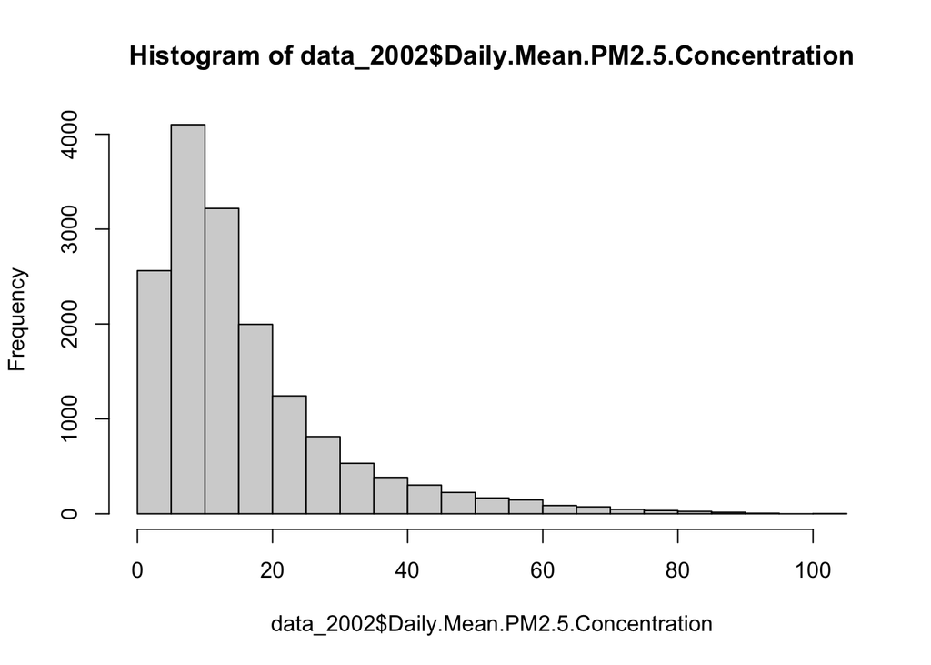

```r
hist(data_2002$Daily.Mean.PM2.5.Concentration)
```

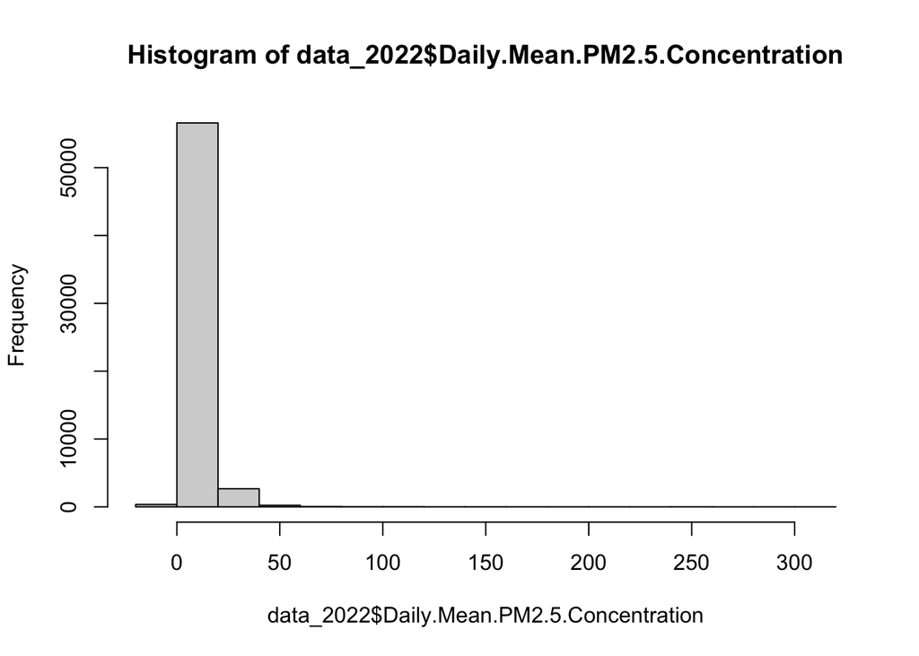

```r
hist(data_2022$Daily.Mean.PM2.5.Concentration)
```

#### Summary:

The 2002 dataset has 15,976 rows and 22 columns, while the 2022 dataset has 59,918 rows and 22 columns. Key variables include the Date of the sample, geographic identifiers like County and Local.Site.Name, the specific monitoring Site.ID, and location data like Site.Latitude and Site.Longitude for mapping. The primary variable for this analysis is the Daily.Mean.PM2.5.Concentration. The summary data shows the 2002 dataset has a mean value of 16.12 µg/m³ and a max value of 104.3 µg/m³, with a right-skewed distribution characterized by many moderate values. In contrast, the 2022 dataset shows a lower mean of 8.414 µg/m³ but a much higher max value of 302.5 µg/m³. The distribution for 2022 is also right-skewed but has a lower central tendency compared to 2002, despite occasional extreme peaks likely caused by wildfire smoke events. Overall, average PM2.5 levels in 2022 are roughly half of 2002 levels, signaling a long-term improvement in California’s air quality, though extreme pollution events are more prominent in the 2022 data.

# Step2

```r
df_combined <- rbind(data_2002, data_2022)

df_combined$Date <- as.Date(df_combined$Date, format = "%m/%d/%Y")
df_combined$year <- as.numeric(format(df_combined$Date, "%Y"))
names(df_combined)[names(df_combined) == "Daily.Mean.PM2.5.Concentration"] <- "pm25"
names(df_combined)[names(df_combined) == "Daily.AQI.Value"] <- "aqi"
names(df_combined)[names(df_combined) == "Site.ID"] <- "site_id"

head(df_combined)
```

```
        Date Source  site_id POC pm25    Units aqi Local.Site.Name
1 2002-01-05    AQS 60010007   1 25.1 ug/m3 LC  81       Livermore
2 2002-01-06    AQS 60010007   1 31.6 ug/m3 LC  93       Livermore
3 2002-01-08    AQS 60010007   1 21.4 ug/m3 LC  74       Livermore
4 2002-01-11    AQS 60010007   1 25.9 ug/m3 LC  82       Livermore
5 2002-01-14    AQS 60010007   1 34.5 ug/m3 LC  98       Livermore
6 2002-01-17    AQS 60010007   1 41.0 ug/m3 LC 115       Livermore
  Daily.Obs.Count Percent.Complete AQS.Parameter.Code AQS.Parameter.Description
1               1              100              88101  PM2.5 - Local Conditions
2               1              100              88101  PM2.5 - Local Conditions
3               1              100              88101  PM2.5 - Local Conditions
4               1              100              88101  PM2.5 - Local Conditions
5               1              100              88101  PM2.5 - Local Conditions
6               1              100              88101  PM2.5 - Local Conditions
  Method.Code                    Method.Description CBSA.Code
```

[output cut: 20 more lines]

```r
tail(df_combined)
```

```
            Date Source  site_id POC pm25    Units aqi      Local.Site.Name
75889 2022-12-01    AQS 61131003   1  3.4 ug/m3 LC  19 Woodland-Gibson Road
75890 2022-12-07    AQS 61131003   1  3.8 ug/m3 LC  21 Woodland-Gibson Road
75891 2022-12-13    AQS 61131003   1  6.0 ug/m3 LC  33 Woodland-Gibson Road
75892 2022-12-19    AQS 61131003   1 34.8 ug/m3 LC  99 Woodland-Gibson Road
75893 2022-12-25    AQS 61131003   1 23.2 ug/m3 LC  77 Woodland-Gibson Road
75894 2022-12-31    AQS 61131003   1  1.0 ug/m3 LC   6 Woodland-Gibson Road
      Daily.Obs.Count Percent.Complete AQS.Parameter.Code
75889               1              100              88101
75890               1              100              88101
75891               1              100              88101
75892               1              100              88101
75893               1              100              88101
75894               1              100              88101
      AQS.Parameter.Description Method.Code
```

[output cut: 27 more lines]

```r
table(df_combined$year)
```

```
 2002  2022
15976 59918
```

# Step3

```r
library(leaflet)
library(dplyr)
sites_unique <- df_combined %>%
  select(year, County, Site.Latitude, Site.Longitude) %>%
  distinct()

leaflet(data = sites_unique) %>%
  addProviderTiles(providers$CartoDB.Positron) %>%
  setView(lng = -119.4179, lat = 36.7783, zoom = 6) %>%
  addCircleMarkers(
    lng = ~Site.Longitude,
    lat = ~Site.Latitude,
    color = ~ifelse(year == 2002, "blue", "red"),
    radius = 3,
    stroke = FALSE,
    fillOpacity = 0.7,
    popup = ~paste(County, year, sep = ", ")
  ) %>%
  addLegend(
    "bottomright",
    colors = c("blue", "red"),
    labels = c("2002", "2022"),
    title = "Year"
  )
```

[interactive chart not shown]

The spatial distribution of PM$_{2.5}$ monitoring sites in California is heavily concentrated in urban and agricultural centers rather than being spread uniformly across the state. For both 2002 and 2022, the majority of sites are clustered in the Los Angeles metropolitan basin, the San Francisco Bay Area, and along the populated corridor of the Central Valley. Rural, mountainous, and desert regions, such as the Sierra Nevada and the Mojave Desert, have very sparse monitor coverage.

Yes, the distribution changed significantly between 2002 and 2022. The primary change was a massive expansion and densification of the monitoring network. This is visible in two main ways, where many more monitoring sites were established within the existing 2002 footprint, providing more detailed data for major metropolitan areas. In addition, the network also expanded geographically into new areas that had little or no monitoring in 2002, improving the overall spatial reach of air quality assessment in the state.

# Step4

```r
data_issues <- df_combined %>%
  group_by(year) %>%
  summarise(
    total_obs = n(),
    missing_obs = sum(is.na(pm25)),
    implausible_obs = sum(pm25 < 0, na.rm = TRUE)
  ) %>%
  mutate(
    missing_proportion = missing_obs / total_obs,
    implausible_proportion = implausible_obs / total_obs
  )
print(data_issues)
```

```
# A tibble: 2 × 6
   year total_obs missing_obs implausible_obs missing_proportion
  <dbl>     <int>       <int>           <int>              <dbl>
1  2002     15976           0               0                  0
2  2022     59918           0             215                  0
# ℹ 1 more variable: implausible_proportion <dbl>
```

The dataset has no missing PM2.5 values in either 2002 or 2022. In 2002, all values were valid. But in 2022, there are 215 negative PM2.5 records (about 0.36% of that year’s data). This means a new data quality issue, negative value, appeared in 2022 that wasn’t present before.

# Step5

```r
library(ggplot2)

df_clean <- df_combined %>%
  filter(!is.na(pm25) & pm25 >= 0)
```

### Level 1: State

```r
state_summary <- df_clean %>%
  group_by(year) %>%
  summarise(
    mean_pm25 = mean(pm25),
    median_pm25 = median(pm25)
  )
print(state_summary)
```

```
# A tibble: 2 × 3
   year mean_pm25 median_pm25
  <dbl>     <dbl>       <dbl>
1  2002     16.1         12
2  2022      8.45         6.8
```

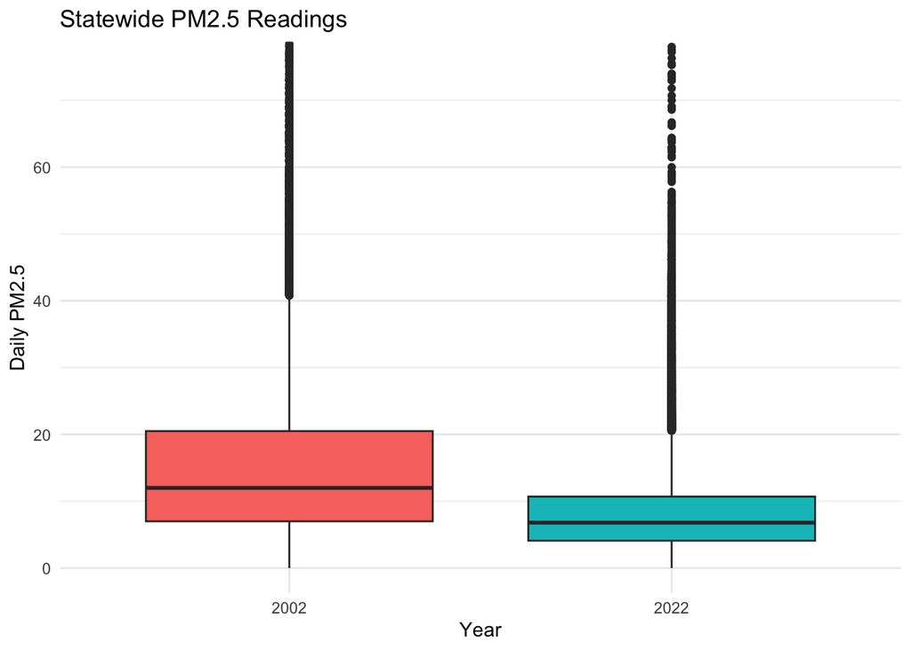

```r
ggplot(df_clean, aes(x = as.factor(year), y = pm25, fill = as.factor(year))) +
  geom_boxplot() +
  coord_cartesian(ylim = c(0, 75)) +
  labs(
    title = "Statewide PM2.5 Readings",
    x = "Year",
    y = "Daily PM2.5"
  ) +
  theme_minimal() +
  guides(fill = "none")
```

### Level 2: County

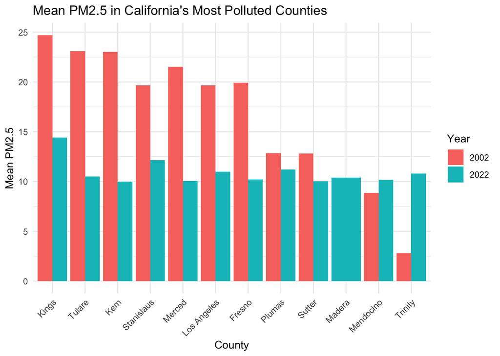

```r
county_summary <- df_clean %>%
  group_by(year, County) %>%
  summarise(mean_pm25 = mean(pm25), .groups = 'drop')


top_counties_list <- county_summary %>%
  filter(year == 2022) %>%
  arrange(desc(mean_pm25)) %>%
  slice(1:12) %>%
  pull(County)

top_county_data <- county_summary %>%
  filter(County %in% top_counties_list)

ggplot(top_county_data, aes(x = reorder(County, -mean_pm25), y = mean_pm25, fill = as.factor(year))) +
  geom_bar(stat = "identity", position = "dodge") +
  labs(
    title = "Mean PM2.5 in California's Most Polluted Counties",
    x = "County",
    y = "Mean PM2.5",
    fill = "Year"
  ) +
  theme_minimal() +
  # Rotate x-axis labels for readability
  theme(axis.text.x = element_text(angle = 45, hjust = 1))
```

### Level 3: City

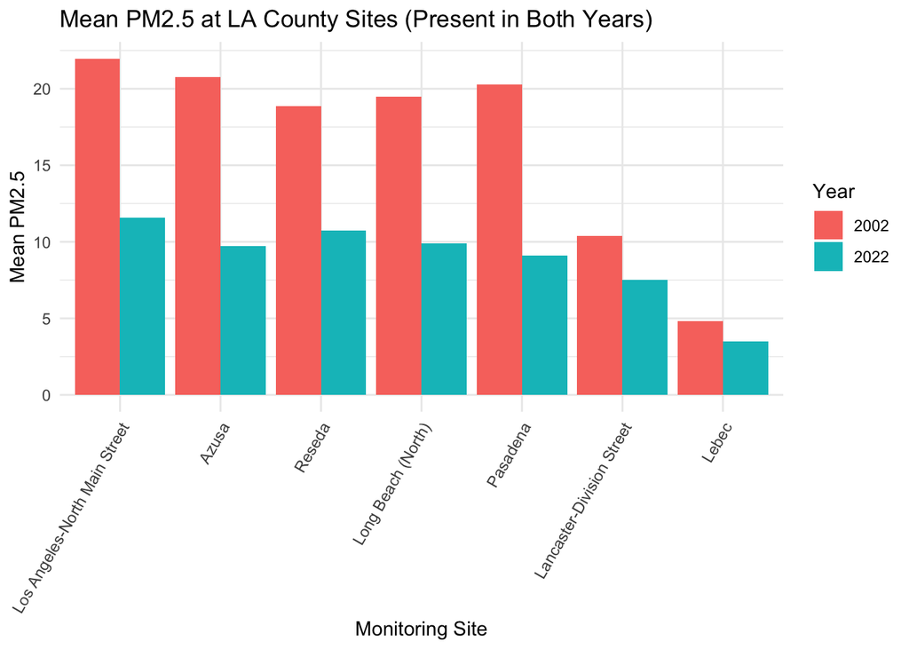

```r
la_sites_summary <- df_clean %>%
  filter(County == "Los Angeles") %>%
  group_by(year, Local.Site.Name) %>%
  summarise(mean_pm25 = mean(pm25), .groups = 'drop')

# sites that have data for both years
sites_with_both_years <- la_sites_summary %>%
  group_by(Local.Site.Name) %>%
  filter(n() == 2) %>%
  ungroup()

  ggplot(sites_with_both_years, aes(x = reorder(Local.Site.Name, -mean_pm25), y = mean_pm25, fill = as.factor(year))) +
  geom_bar(stat = "identity", position = "dodge") +
  labs(
    title = "Mean PM2.5 at LA County Sites (Present in Both Years)",
    x = "Monitoring Site",
    y = "Mean PM2.5",
    fill = "Year"
  ) +
  theme_minimal() +
  theme(axis.text.x = element_text(angle = 60, hjust = 1))
```

### Level 1: State

At the statewide level, there has been a dramatic reduction in PM2.5 pollution. The summary statistics show the statewide mean PM2.5 fell from 16.1μg/m3 in 2002 to 8.45μg/m3 in 2022, a drop of nearly 50%. The boxplot visualization confirms this by showing that the entire distribution of daily readings, including the median and the typical range of values, was substantially lower in 2022 than in 2002.

### Level 3: City (Los Angeles County Sites)

By refining the analysis to only include Los Angeles County sites with continuous data from both 2002 and 2022, the trend of improved air quality is strongly reinforced. This comparison shows that every single one of these long-standing monitoring sites, from Los Angeles-North Main Street to Lebec, experienced a substantial drop in mean PM2.5 levels. This confirms the air quality improvements are widespread and consistent over the two decades across different communities in the county.